# The February 6, 2023 Kahramanmaraş Earthquake and Migration Dynamics

Damage, Displacement, and Recovery in 11 Earthquake-Affected Provinces

Author

Şevval Miray Başar and Büşra Halil

Published

May 19, 2026

```r
pop <- read_excel(file.path(PROJE, "tr_nufus.xlsx")) |>
  rename(year = 1, province_raw = 2, total = 3, male = 4, female = 5) |>
  mutate(
    year = as.integer(year),
    total = num_clean(total),
    male = num_clean(male),
    female = num_clean(female),
    province = normalize_city(province_raw),
    label = PROVINCE_LABELS[province]
  ) |>
  filter(province %in% EQ_KEYS) |>
  arrange(province, year) |>
  group_by(province) |>
  mutate(
    pop_change = total - lag(total),
    pop_change_pct = pop_change / lag(total) * 100,
    sex_ratio = male / female * 100
  ) |>
  ungroup()

damage <- read_excel(file.path(PROJE, "deprem_hasar_tablosu.xlsx")) |>
  clean_names() |>
  rename(
    province_raw = il,
    heavy = toplam_agir_yikik_konut_sayisi,
    medium = orta_hasarli_konut_sayisi,
    light = az_hasarli_konut_sayisi
  ) |>
  filter(!is.na(province_raw), province_raw != "Bölge Toplam") |>
  mutate(
    province = normalize_city(province_raw),
    heavy = num_clean(heavy),
    medium = num_clean(medium),
    light = num_clean(light),
    total_damage = heavy + medium + light
  ) |>
  filter(province %in% EQ_KEYS) |>
  left_join(
    pop |> filter(year == 2022) |> select(province, pop_2022 = total),
    by = "province"
  ) |>
  mutate(
    heavy_per_1000 = heavy / pop_2022 * 1000,
    medium_per_1000 = medium / pop_2022 * 1000,
    light_per_1000 = light / pop_2022 * 1000,
    total_damage_per_1000 = total_damage / pop_2022 * 1000,
    label = PROVINCE_LABELS[province]
  )

flows_2023 <- read_excel(
  file.path(PROJE, "deprem_2023_goc_akislari_duzenlenmis.xlsx"),
  sheet = "Flow_2023_All"
) |>
  clean_names() |>
  transmute(
    from = normalize_city(origin_province),
    to = normalize_city(destination_province),
    value = num_clean(migration_count)
  ) |>
  filter(from %in% EQ_KEYS, value > 0)

mig_raw <- read_excel(file.path(PROJE, "deprem_goc_ham_filtreli.xlsx"), skip = 2) |>
  clean_names() |>
  filter(!is.na(yil)) |>
  transmute(
    year = as.integer(yil),
    dest = normalize_city(goc_alan_il_adi),
    origin = normalize_city(goc_veren_il_adi),
    flow = num_clean(aldigi_goc)
  )

net_migration <- bind_rows(
  mig_raw |> transmute(year, province = dest, inflow = flow, outflow = 0),
  mig_raw |> transmute(year, province = origin, inflow = 0, outflow = flow)
) |>
  filter(province %in% EQ_KEYS) |>
  group_by(year, province) |>
  summarise(
    inflow = sum(inflow, na.rm = TRUE),
    outflow = sum(outflow, na.rm = TRUE),
    net_migration = inflow - outflow,
    .groups = "drop"
  ) |>
  left_join(pop |> select(year, province, total), by = c("year", "province")) |>
  mutate(
    net_migration_rate = net_migration / total * 1000,
    label = PROVINCE_LABELS[province]
  )

analysis_data <- pop |>
  filter(year %in% c(2022, 2023)) |>
  select(province, label, year, total) |>
  pivot_wider(names_from = year, values_from = total, names_prefix = "pop_") |>
  mutate(
    pop_change = pop_2023 - pop_2022,
    pop_change_pct = pop_change / pop_2022 * 100
  ) |>
  left_join(
    damage |> select(province, heavy_per_1000, total_damage_per_1000),
    by = "province"
  )

cover_stats <- tibble(
  net_loss_2023 = net_migration |>
    filter(year == 2023) |>
    summarise(x = sum(net_migration, na.rm = TRUE)) |>
    pull(x),
  affected_provinces = length(EQ_KEYS),
  period_years = max(pop$year, na.rm = TRUE) - min(pop$year, na.rm = TRUE) + 1
)

save(
  pop, damage, flows_2023, net_migration, analysis_data,
  file = file.path(PROJE, "final_earthquake_migration_project.RData")
)
```

Population & Migration Research · Turkey 2018–2025

The February 6 Earthquake and Migration Dynamics

A data-driven analysis of damage exposure, internal migration flows, population loss, and demographic recovery across 11 affected provinces.

Damage Intensity Internal Migration Population Recovery TÜİK & AFAD Data

293,121

Net migration loss in earthquake provinces, 2023

11

Earthquake-affected provinces analyzed

8

Years of demographic data, 2018–2025

# 1 Introduction

# 2 Data and Preprocessing

The final processed dataset is available here:  
Download final RData file

```r
tibble(
  Dataset = c(
    "tr_nufus.xlsx",
    "deprem_hasar_tablosu.xlsx",
    "deprem_2023_goc_akislari_duzenlenmis.xlsx",
    "deprem_goc_ham_filtreli.xlsx",
    "I_ller_Arası_Go_c_.xlsx"
  ),
  Content = c(
    "Annual province-level population by sex",
    "Housing damage by province and damage severity",
    "Cleaned 2023 migration flows from earthquake provinces",
    "Annual inter-provincial migration data",
    "Full 81x81 inter-provincial migration table"
  ),
  Period = c("2018–2025", "2023", "2023", "2018–2025", "2008–2025"),
  Main_Use = c(
    "Population trend and recovery analysis",
    "Damage intensity calculation",
    "Migration flow visualization",
    "Net migration rate analysis",
    "Supplementary Ankara analysis"
  )
) |>
  knitr::kable()
```

Summary of datasets used in the project.

| Dataset | Content | Period | Main_Use |
| --- | --- | --- | --- |
| tr_nufus.xlsx | Annual province-level population by sex | 2018–2025 | Population trend and recovery analysis |
| deprem_hasar_tablosu.xlsx | Housing damage by province and damage severity | 2023 | Damage intensity calculation |
| deprem_2023_goc_akislari_duzenlenmis.xlsx | Cleaned 2023 migration flows from earthquake provinces | 2023 | Migration flow visualization |
| deprem_goc_ham_filtreli.xlsx | Annual inter-provincial migration data | 2018–2025 | Net migration rate analysis |
| I_ller_Arası_Go_c_.xlsx | Full 81x81 inter-provincial migration table | 2008–2025 | Supplementary Ankara analysis |

# 3 Exploratory Data Analysis

## 3.1 Damage Intensity

```r
geo_url <- "https://raw.githubusercontent.com/alpers/Turkey-Maps-GeoJSON/master/tr-cities.json"

tr_map <- sf::st_read(geo_url, quiet = TRUE) |>
  mutate(province = normalize_city(name))

damage_map <- tr_map |>
  left_join(damage, by = "province")

pal <- leaflet::colorBin(
  palette = c("#ffffcc", "#fed976", "#fd8d3c", "#e31a1c", "#5c0011"),
  domain = damage_map$heavy_per_1000,
  bins = c(0, 10, 30, 60, 90, 130),
  na.color = "#eeeeee",
  right = FALSE
)

city_centers <- sf::st_centroid(tr_map) |>
  filter(province %in% EQ_KEYS)

earthquake_centers <- tibble::tribble(
  ~event, ~location, ~lat, ~lng, ~depth_km, ~magnitude,
  "1st earthquake", "Pazarcık, Kahramanmaraş", 37.236, 37.057, 8.6, 7.7,
  "2nd earthquake", "Elbistan, Kahramanmaraş", 38.089, 37.239, 7.0, 7.6
)

quake_icon <- leaflet::awesomeIcons(
  icon = "star",
  iconColor = "white",
  markerColor = "red",
  library = "fa"
)

leaflet::leaflet(damage_map) |>
  leaflet::addProviderTiles("CartoDB.Positron") |>
  leaflet::addPolygons(
    fillColor = ~pal(heavy_per_1000),
    fillOpacity = ~ifelse(is.na(heavy_per_1000), 0.12, 0.78),
    color = "white",
    weight = 1,
    popup = ~ifelse(
      is.na(heavy_per_1000),
      paste0("<b>", name, "</b><br>Not included in earthquake damage data."),
      paste0(
        "<b>", label, "</b><br>",
        "Heavy/collapsed housing: ", format(heavy, big.mark = ","), "<br>",
        "Medium damaged housing: ", format(medium, big.mark = ","), "<br>",
        "Light damaged housing: ", format(light, big.mark = ","), "<br>",
        "Heavy damage per 1,000 residents: ", round(heavy_per_1000, 1), "<br>",
        "Total damage per 1,000 residents: ", round(total_damage_per_1000, 1)
      )
    )
  ) |>
  leaflet::addLabelOnlyMarkers(
    data = city_centers,
    label = ~PROVINCE_LABELS[province],
    labelOptions = leaflet::labelOptions(
      noHide = TRUE,
      direction = "center",
      textOnly = TRUE,
      style = list(
        "font-size" = "12px",
        "font-weight" = "bold",
        "color" = "black",
        "text-shadow" = "1px 1px 5px white, -1px -1px 5px white"
      )
    )
  ) |>
  leaflet::addAwesomeMarkers(
    data = earthquake_centers,
    lng = ~lng,
    lat = ~lat,
    icon = quake_icon,
    label = ~paste0(location, " | Mw ", magnitude),
    popup = ~paste0(
      "<b>", event, "</b><br>",
      "Location: ", location, "<br>",
      "Magnitude: Mw ", magnitude, "<br>",
      "Focal depth: ", depth_km, " km"
    )
  ) |>
  leaflet::addLegend(
    pal = pal,
    values = damage_map$heavy_per_1000,
    title = htmltools::HTML(
      "<div style='font-size:11px; line-height:1.15;'>
      Heavy / collapsed<br>housing per 1,000 residents
      </div>"
    ),
    position = "bottomright",
    opacity = 0.85
  )
```

[interactive chart not shown]

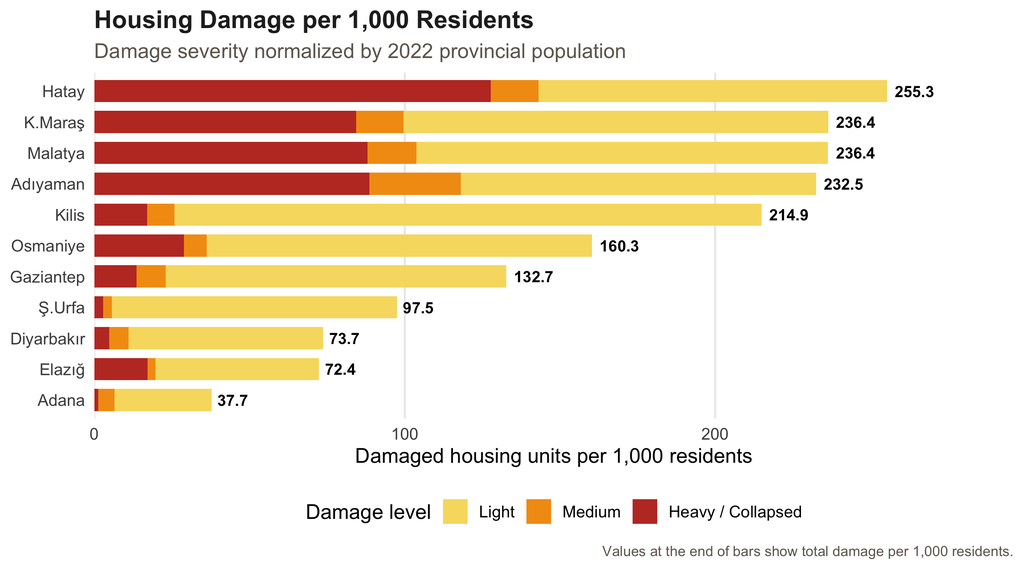

Housing damage intensity by province, normalized by 2022 population.

```r
damage_long <- damage |>
  select(label, light_per_1000, medium_per_1000, heavy_per_1000, total_damage_per_1000) |>
  arrange(total_damage_per_1000) |>
  mutate(label = factor(label, levels = label)) |>
  pivot_longer(
    c(light_per_1000, medium_per_1000, heavy_per_1000),
    names_to = "type",
    values_to = "value"
  ) |>
  mutate(
    type = factor(
      type,
      levels = c("light_per_1000", "medium_per_1000", "heavy_per_1000"),
      labels = c("Light", "Medium", "Heavy / Collapsed")
    )
  )

ggplot(damage_long, aes(value, label, fill = type)) +
  geom_col(width = 0.72) +
  geom_text(
    data = damage |> mutate(label = factor(label, levels = levels(damage_long$label))),
    aes(total_damage_per_1000, label, label = round(total_damage_per_1000, 1)),
    inherit.aes = FALSE,
    hjust = -0.2,
    size = 3.5,
    fontface = "bold"
  ) +
  scale_fill_manual(values = c(
    "Light" = "#F7DC6F",
    "Medium" = "#F39C12",
    "Heavy / Collapsed" = "#C0392B"
  )) +
  scale_x_continuous(expand = expansion(mult = c(0, 0.16))) +
  labs(
    title = "Housing Damage per 1,000 Residents",
    subtitle = "Damage severity normalized by 2022 provincial population",
    x = "Damaged housing units per 1,000 residents",
    y = NULL,
    fill = "Damage level",
    caption = "Values at the end of bars show total damage per 1,000 residents."
  ) +
  theme(
    panel.grid.major.y = element_blank(),
    legend.position = "bottom",
    plot.title = element_text(face = "bold")
  )
```

## 3.2 Migration Overview

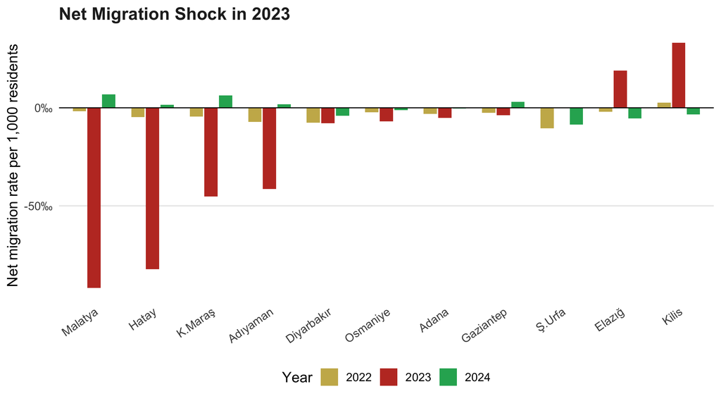

Net migration rate per 1,000 residents in 2022, 2023, and 2024.

```r
net_migration |>
  filter(year %in% c(2022, 2023, 2024)) |>
  mutate(label = fct_reorder(label, if_else(year == 2023, net_migration_rate, NA_real_), mean, na.rm = TRUE)) |>
  ggplot(aes(label, net_migration_rate, fill = factor(year))) +
  geom_col(position = position_dodge(0.75), width = 0.68) +
  geom_hline(yintercept = 0, linewidth = 0.4) +
  scale_fill_manual(values = c("2022" = "#c9b458", "2023" = "#c0392b", "2024" = "#27ae60")) +
  scale_y_continuous(labels = label_number(suffix = "‰")) +
  labs(
    title = "Net Migration Shock in 2023",
    x = NULL,
    y = "Net migration rate per 1,000 residents",
    fill = "Year"
  ) +
  theme(
    axis.text.x = element_text(angle = 35, hjust = 1),
    panel.grid.major.x = element_blank(),
    legend.position = "bottom",
    plot.title = element_text(face = "bold")
  )
```

## 3.3 Population Trends

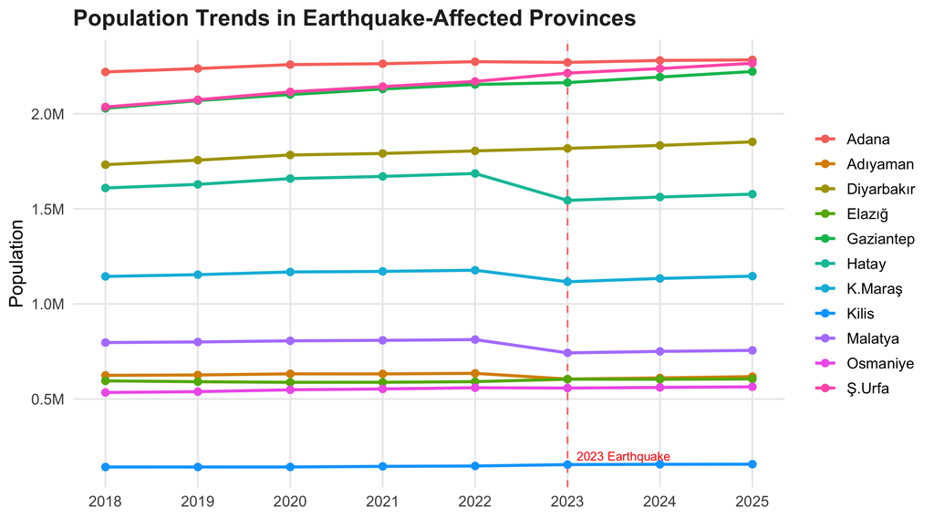

Population trend in 11 earthquake-affected provinces, 2018–2025.

```r
pop |>
  ggplot(aes(year, total / 1e6, color = label, group = label)) +
  geom_vline(xintercept = 2023, linetype = "dashed", color = "red", alpha = 0.55) +
  geom_line(linewidth = 1) +
  geom_point(size = 2) +
  annotate("text", x = 2023.1, y = 0.2, label = "2023 Earthquake", hjust = 0, color = "red", size = 3) +
  scale_x_continuous(breaks = 2018:2025) +
  scale_y_continuous(labels = label_number(suffix = "M")) +
  labs(
    title = "Population Trends in Earthquake-Affected Provinces",
    x = NULL,
    y = "Population",
    color = NULL
  ) +
  theme(
    legend.position = "right",
    panel.grid.minor = element_blank(),
    plot.title = element_text(face = "bold")
  )
```

# 4 Main Analysis

## 4.1 Interactive Migration Flow Map

```r
coords <- tribble(
  ~province, ~lat, ~lon,
  "ADANA",37.00,35.32, "ADIYAMAN",37.76,38.28,
  "DIYARBAKIR",37.91,40.22, "ELAZIG",38.67,39.22,
  "GAZIANTEP",37.07,37.38, "HATAY",36.20,36.16,
  "KAHRAMANMARAS",37.58,36.92, "KILIS",36.72,37.12,
  "MALATYA",38.35,38.31, "OSMANIYE",37.07,36.25,
  "SANLIURFA",37.16,38.80, "ANKARA",39.93,32.86,
  "ISTANBUL",41.02,28.97, "MERSIN",36.80,34.64,
  "ANTALYA",36.90,30.70, "IZMIR",38.42,27.14,
  "KONYA",37.87,32.48, "KAYSERI",38.72,35.49,
  "MARDIN",37.31,40.74, "BURSA",40.18,29.06,
  "KOCAELI",40.77,29.95, "MUGLA",37.21,28.36,
  "AYDIN",37.85,27.84, "ESKISEHIR",39.77,30.52,
  "SAMSUN",41.29,36.33, "SIVAS",39.75,37.02
)

labels <- tribble(
  ~province, ~label,
  "ADANA","Adana", "ADIYAMAN","Adıyaman",
  "DIYARBAKIR","Diyarbakır", "ELAZIG","Elazığ",
  "GAZIANTEP","Gaziantep", "HATAY","Hatay",
  "KAHRAMANMARAS","K.Maraş", "KILIS","Kilis",
  "MALATYA","Malatya", "OSMANIYE","Osmaniye",
  "SANLIURFA","Ş.Urfa", "ANKARA","Ankara",
  "ISTANBUL","İstanbul", "MERSIN","Mersin",
  "ANTALYA","Antalya", "IZMIR","İzmir",
  "KONYA","Konya", "KAYSERI","Kayseri",
  "MARDIN","Mardin", "BURSA","Bursa",
  "KOCAELI","Kocaeli", "MUGLA","Muğla",
  "AYDIN","Aydın", "ESKISEHIR","Eskişehir",
  "SAMSUN","Samsun", "SIVAS","Sivas"
)

flows_map <- flows_2023 |>
  filter(value >= 500, to %in% coords$province) |>
  group_by(from_key = from, to_key = to) |>
  summarise(value = sum(value), .groups = "drop")

tr_simple <- tr_map |>
  st_transform(4326) |>
  st_simplify(dTolerance = 0.03) |>
  left_join(damage |> select(province, damage = heavy_per_1000), by = "province")

map_geojson <- geojsonsf::sf_geojson(tr_simple)
flow_json <- jsonlite::toJSON(flows_map, auto_unbox = TRUE)
coord_json <- jsonlite::toJSON(coords, auto_unbox = TRUE)
label_json <- jsonlite::toJSON(labels, auto_unbox = TRUE)

button_list <- c("ALL", EQ_KEYS)
button_labels <- c("All", labels$label[match(EQ_KEYS, labels$province)])

buttons_html <- paste0(
  paste0(
    "<button class='prov-btn", ifelse(button_list == "ALL", " active", ""),
    "' onclick=\"setFilter('", button_list, "', this)\">",
    button_labels, "</button>"
  ),
  collapse = ""
)

HTML(glue::glue('
<style>
#controls {{ display:flex; gap:8px; flex-wrap:wrap; align-items:center; margin-bottom:8px; font-size:13px; }}
.prov-btn {{ font-size:11px; padding:4px 9px; border-radius:18px; cursor:pointer; border:1px solid #ccc; background:#f7f7f7; }}
.prov-btn.active {{ border-color:#8b1e1e; background:#fdecea; color:#8b1e1e; font-weight:bold; }}
#tooltip {{ position:fixed; background:white; border:1px solid #ccc; border-radius:8px; padding:8px 12px; font-size:12px; pointer-events:none; opacity:0; box-shadow:0 2px 8px rgba(0,0,0,.15); z-index:999; }}
#legend {{ display:flex; gap:16px; font-size:12px; margin-top:8px; flex-wrap:wrap; }}
.leg-item {{ display:flex; align-items:center; gap:5px; }}
.leg-dot {{ width:11px; height:11px; border-radius:50%; }}
</style>
<div id="tooltip"></div>
<div id="controls"><b>Filter by origin:</b>{buttons_html}</div>
<svg id="mapsvg" width="100%" viewBox="0 0 680 420" style="display:block">
  <g id="map-layer"></g><g id="flows-layer"></g><g id="dots-layer"></g><g id="labels-layer"></g>
</svg>
<div id="legend">
  <div class="leg-item"><div class="leg-dot" style="background:#f0d27a"></div><span>Low damage</span></div>
  <div class="leg-item"><div class="leg-dot" style="background:#e17035"></div><span>Medium damage</span></div>
  <div class="leg-item"><div class="leg-dot" style="background:#4b000f"></div><span>High damage</span></div>
  <div class="leg-item"><div class="leg-dot" style="background:#1a5276"></div><span>Destination province</span></div>
</div>
<script>
const TURKEY = {map_geojson};
const FLOWS = {flow_json};
const COORDS_RAW = {coord_json};
const LABELS_RAW = {label_json};
const COORDS = Object.fromEntries(COORDS_RAW.map(d => [d.province, [d.lat, d.lon]]));
const LABELS = Object.fromEntries(LABELS_RAW.map(d => [d.province, d.label]));
const LON_MIN=25.5, LON_MAX=45.2, LAT_MIN=35.4, LAT_MAX=42.6;
const SVG_X_MIN=35, SVG_X_MAX=610, SVG_Y_MIN=38, SVG_Y_MAX=315;

function toSVG(lat, lon) {{
  const x = SVG_X_MIN + (lon - LON_MIN) / (LON_MAX - LON_MIN) * (SVG_X_MAX - SVG_X_MIN);
  const y = SVG_Y_MAX - (lat - LAT_MIN) / (LAT_MAX - LAT_MIN) * (SVG_Y_MAX - SVG_Y_MIN);
  return [x, y];
}}

function damageColor(v) {{
  if (v == null || isNaN(v)) return "#d6d6d6";
  if (v < 10) return "#f0d27a";
  if (v < 30) return "#e69f45";
  if (v < 60) return "#d95f0e";
  if (v < 90) return "#b30000";
  return "#4b000f";
}}

function drawMap() {{
  const ml = document.getElementById("map-layer");
  TURKEY.features.forEach(f => {{
    const damage = f.properties.damage;
    const coords = f.geometry.coordinates;
    const polys = f.geometry.type === "MultiPolygon" ? coords : [coords];
    polys.forEach(poly => {{ poly.forEach(ring => {{
      let d = "";
      ring.forEach((pt, i) => {{
        const [x, y] = toSVG(pt[1], pt[0]);
        d += (i === 0 ? "M" : "L") + x.toFixed(1) + " " + y.toFixed(1) + " ";
      }});
      d += "Z";
      const path = document.createElementNS("http://www.w3.org/2000/svg","path");
      path.setAttribute("d", d);
      path.setAttribute("fill", damageColor(damage));
      path.setAttribute("fill-opacity", damage == null ? "0.48" : "0.88");
      path.setAttribute("stroke", "#ffffff");
      path.setAttribute("stroke-width", "0.7");
      ml.appendChild(path);
    }}); }});
  }});
}}

function dotR(v, maxDest) {{ return 5 + (v / maxDest) * 13; }}

function curvePath(x1, y1, x2, y2) {{
  const mx=(x1+x2)/2, my=(y1+y2)/2;
  const dx=x2-x1, dy=y2-y1, len=Math.sqrt(dx*dx+dy*dy);
  const bulge=Math.min(len*0.22,45);
  const cx=mx + (-dy/len)*bulge;
  const cy=my + ( dx/len)*bulge;
  return `M ${{x1.toFixed(1)}} ${{y1.toFixed(1)}} Q ${{cx.toFixed(1)}} ${{cy.toFixed(1)}} ${{x2.toFixed(1)}} ${{y2.toFixed(1)}}`;
}}

let activeFilter = "ALL";

function setFilter(p, btn) {{
  activeFilter = p;
  document.querySelectorAll(".prov-btn").forEach(b => b.classList.remove("active"));
  btn.classList.add("active");
  render();
}}

const tooltip = document.getElementById("tooltip");

function showTip(e, html) {{ tooltip.innerHTML = html; tooltip.style.opacity = 1; moveTip(e); }}
function moveTip(e) {{ tooltip.style.left = (e.clientX + 14) + "px"; tooltip.style.top = (e.clientY - 28) + "px"; }}
function hideTip() {{ tooltip.style.opacity = 0; }}

function render() {{
  const fl = document.getElementById("flows-layer");
  const dl = document.getElementById("dots-layer");
  const ll = document.getElementById("labels-layer");
  fl.innerHTML = ""; dl.innerHTML = ""; ll.innerHTML = "";

  const visible = activeFilter === "ALL" ? FLOWS : FLOWS.filter(f => f.from_key === activeFilter);
  const destTotals = {{}};

  visible.forEach(f => destTotals[f.to_key] = (destTotals[f.to_key] || 0) + f.value);
  const maxDest = Math.max(...Object.values(destTotals), 1);

  visible.forEach(f => {{
    if (!COORDS[f.from_key] || !COORDS[f.to_key]) return;
    const [lat1, lon1] = COORDS[f.from_key];
    const [lat2, lon2] = COORDS[f.to_key];
    const [x1, y1] = toSVG(lat1, lon1);
    const [x2, y2] = toSVG(lat2, lon2);

    const path = document.createElementNS("http://www.w3.org/2000/svg","path");
    path.setAttribute("d", curvePath(x1,y1,x2,y2));
    path.setAttribute("fill", "none");
    path.setAttribute("stroke", "#8b1e1e");
    path.setAttribute("stroke-width", "1.8");
    path.setAttribute("stroke-opacity", "0.52");
    path.setAttribute("stroke-linecap", "round");
    path.addEventListener("mouseenter", e => showTip(e, `<b>${{LABELS[f.from_key]}} → ${{LABELS[f.to_key]}}</b><br>${{Number(f.value).toLocaleString("tr-TR")}} people`));
    path.addEventListener("mousemove", moveTip);
    path.addEventListener("mouseleave", hideTip);
    fl.appendChild(path);
  }});

  const allProvs = new Set();
  visible.forEach(f => {{ allProvs.add(f.from_key); allProvs.add(f.to_key); }});

  allProvs.forEach(p => {{
    if (!COORDS[p]) return;
    const [lat, lon] = COORDS[p];
    const [x, y] = toSVG(lat, lon);
    const isDest = destTotals[p] > 0;

    if (isDest) {{
      const dot = document.createElementNS("http://www.w3.org/2000/svg","circle");
      dot.setAttribute("cx", x); dot.setAttribute("cy", y);
      dot.setAttribute("r", dotR(destTotals[p], maxDest));
      dot.setAttribute("fill", "#1a5276");
      dot.setAttribute("opacity", "0.80");
      dot.setAttribute("stroke", "white");
      dot.setAttribute("stroke-width", "1.5");
      dot.addEventListener("mouseenter", e => showTip(e, `<b>${{LABELS[p]}}</b><br>${{Number(destTotals[p]).toLocaleString("tr-TR")}} people`));
      dot.addEventListener("mousemove", moveTip);
      dot.addEventListener("mouseleave", hideTip);
      dl.appendChild(dot);
    }}

    const text = document.createElementNS("http://www.w3.org/2000/svg","text");
    text.setAttribute("x", x + 7);
    text.setAttribute("y", y - 7);
    text.setAttribute("font-size", "10");
    text.setAttribute("font-weight", "700");
    text.setAttribute("fill", "#111");
    text.setAttribute("stroke", "white");
    text.setAttribute("stroke-width", "2.8");
    text.setAttribute("paint-order", "stroke");
    text.textContent = LABELS[p] || p;
    ll.appendChild(text);
  }});
}}

drawMap();
render();
</script>
'))
```

**Filter by origin:**

Low damage

Medium damage

High damage

Destination province

```r
flows_2023 |>
  group_by(to) |>
  summarise(total_inflow = sum(value), .groups = "drop") |>
  slice_max(total_inflow, n = 15) |>
  mutate(
    label = if_else(to %in% names(PROVINCE_LABELS), PROVINCE_LABELS[to], str_to_title(to)),
    label = fct_reorder(label, total_inflow)
  ) |>
  ggplot(aes(total_inflow, label)) +
  geom_col(fill = "#1a5276", width = 0.7) +
  scale_x_continuous(labels = label_number(suffix = "K", scale = 1 / 1000)) +
  labs(
    title = "Top Destination Provinces in 2023",
    x = "Incoming migration from earthquake provinces",
    y = NULL
  ) +
  theme(panel.grid.major.y = element_blank())
```

[output not shown]

## 4.2 Top Receiving Provinces

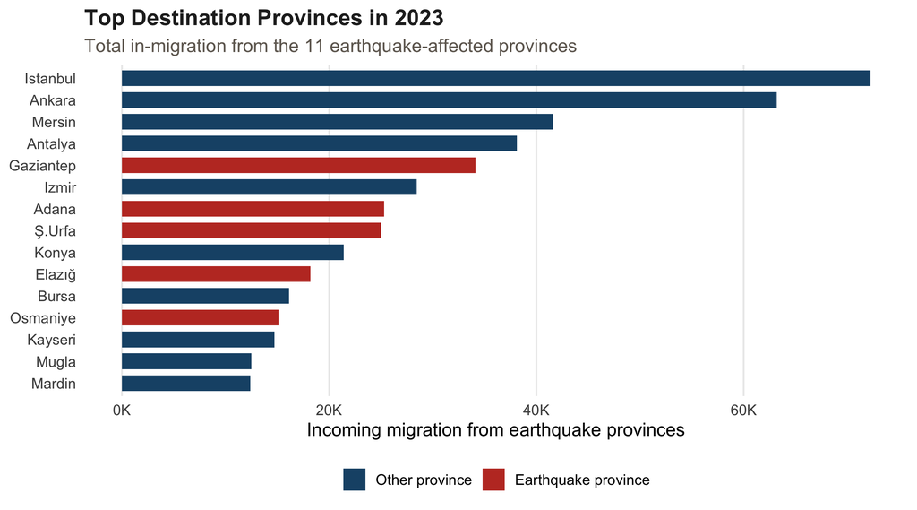

Top destination provinces receiving migrants from earthquake provinces in 2023.

```r
flows_2023 |>
  group_by(to) |>
  summarise(total_inflow = sum(value), .groups = "drop") |>
  slice_max(total_inflow, n = 15) |>
  mutate(
    label = if_else(to %in% names(PROVINCE_LABELS), PROVINCE_LABELS[to], str_to_title(to)),
    is_eq = to %in% EQ_KEYS,
    label = fct_reorder(label, total_inflow)
  ) |>
  ggplot(aes(total_inflow, label, fill = is_eq)) +
  geom_col(width = 0.72) +
  scale_fill_manual(
    values = c("TRUE" = "#c0392b", "FALSE" = "#1a5276"),
    labels = c("Other province", "Earthquake province")
  ) +
  scale_x_continuous(labels = label_number(suffix = "K", scale = 1 / 1000)) +
  labs(
    title = "Top Destination Provinces in 2023",
    subtitle = "Total in-migration from the 11 earthquake-affected provinces",
    x = "Incoming migration from earthquake provinces",
    y = NULL,
    fill = NULL
  ) +
  theme(
    panel.grid.major.y = element_blank(),
    legend.position = "bottom",
    plot.title = element_text(face = "bold")
  )
```

## 4.3 Migration Routes from the Three Hardest-Hit Provinces

Hatay, Malatya, and Kahramanmaraş are among the provinces hardest hit by the earthquake in terms of both the intensity of severe damage and absolute population loss. Since these three provinces constitute a large part of the recorded migration flows in 2023, they were selected as focal points in determining the target provinces and comparing migration routes.

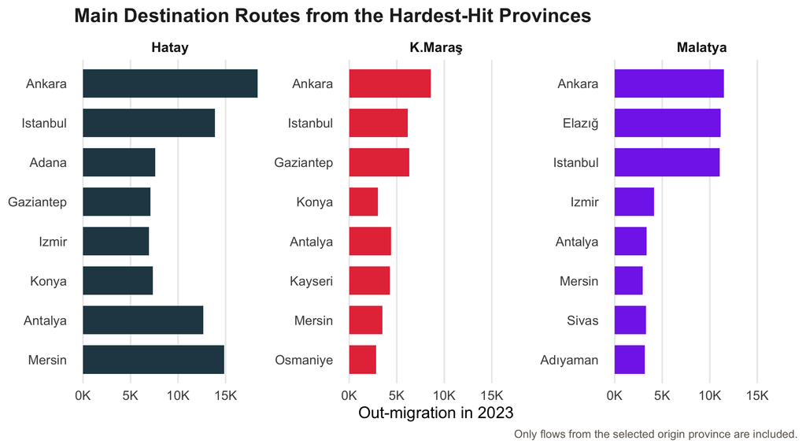

Top destination provinces for out-migrants from Hatay, Malatya and Kahramanmaraş in 2023.

```r
hardest_hit <- c("HATAY", "MALATYA", "KAHRAMANMARAS")

flows_2023 |>
  filter(from %in% hardest_hit) |>
  group_by(from, to) |>
  summarise(outflow = sum(value, na.rm = TRUE), .groups = "drop") |>
  group_by(from) |>
  slice_max(outflow, n = 8, with_ties = FALSE) |>
  ungroup() |>
  mutate(
    origin_label = PROVINCE_LABELS[from],
    dest_label = if_else(to %in% names(PROVINCE_LABELS), PROVINCE_LABELS[to], str_to_title(to)),
    dest_label = fct_reorder(dest_label, outflow)
  ) |>
  ggplot(aes(outflow, dest_label, fill = origin_label)) +
  geom_col(show.legend = FALSE, width = 0.72) +
  facet_wrap(~origin_label, scales = "free_y", ncol = 3) +
  scale_fill_manual(values = c("Hatay" = "#264653", "Malatya" = "#8338ec", "K.Maraş" = "#e63946")) +
  scale_x_continuous(labels = label_number(suffix = "K", scale = 1 / 1000)) +
  labs(
    title = "Main Destination Routes from the Hardest-Hit Provinces",
    x = "Out-migration in 2023",
    y = NULL,
    caption = "Only flows from the selected origin province are included."
  ) +
  theme(
    strip.text = element_text(face = "bold", size = 11),
    panel.grid.major.y = element_blank()
  )
```

## 4.4 Damage Intensity and Population Loss

This graph addresses the question of whether there is a measurable relationship between physical destruction and demographic loss. This scatter plot, where each point shows the number of severely damaged/collapsed houses per 1,000 people on the horizontal axis and the percentage change in population between 2022 and 2023 on the vertical axis, indicates that as the intensity of severe damage increases, population losses also deepen.

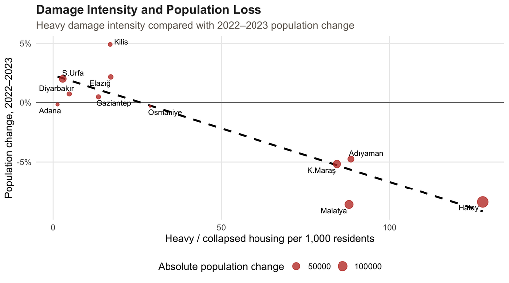

Relationship between heavy damage intensity and population change from 2022 to 2023.

```r
ggplot(analysis_data, aes(x = heavy_per_1000, y = pop_change_pct, label = label)) +
  geom_hline(yintercept = 0, color = "gray40", linewidth = 0.4) +
  geom_smooth(method = "lm", se = FALSE, linetype = "dashed", color = "black") +
  geom_point(aes(size = abs(pop_change)), color = "#c0392b", alpha = 0.78) +
  ggrepel::geom_text_repel(size = 3.4, max.overlaps = 20) +
  scale_y_continuous(labels = function(x) paste0(x, "%")) +
  labs(
    title = "Damage Intensity and Population Loss",
    subtitle = "Heavy damage intensity compared with 2022–2023 population change",
    x = "Heavy / collapsed housing per 1,000 residents",
    y = "Population change, 2022–2023",
    size = "Absolute population change"
  ) +
  theme(legend.position = "bottom")
```

# 5 Recovery Status by 2025

The recovery gap shows the extent to which the actual 2025 population of each province deviates from the expected population based on the pre-earthquake (2018–2022) trend. Positive values indicate that the expected trend has been exceeded, while negative values indicate that a persistent demographic gap continues.

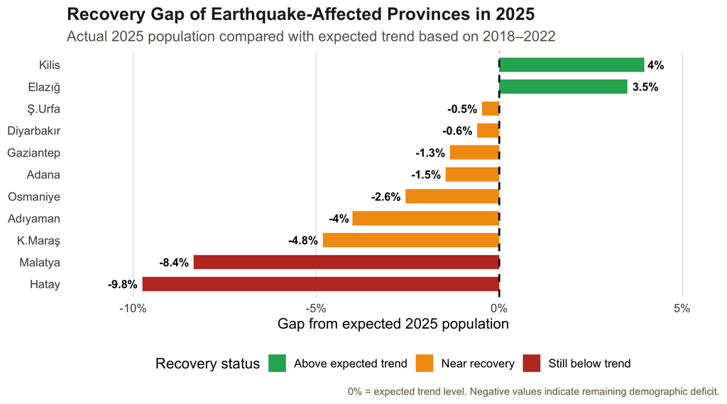

Recovery gap in 2025 relative to expected population based on 2018–2022 trend.

```r
recovery <- pop |>
  group_by(province, label) |>
  group_modify(~{
    fit <- lm(total ~ year, data = .x |> filter(year <= 2022))
    tibble(
      expected_2025 = as.numeric(predict(fit, newdata = tibble(year = 2025))),
      actual_2025 = .x$total[.x$year == 2025]
    )
  }) |>
  ungroup() |>
  mutate(
    recovery_gap_pct = (actual_2025 - expected_2025) / expected_2025 * 100,
    status = case_when(
      recovery_gap_pct >= 0 ~ "Above expected trend",
      recovery_gap_pct >= -5 ~ "Near recovery",
      TRUE ~ "Still below trend"
    )
  )

ggplot(recovery, aes(recovery_gap_pct, reorder(label, recovery_gap_pct), fill = status)) +
  geom_col(width = 0.65) +
  geom_vline(xintercept = 0, linetype = "dashed", linewidth = 0.8) +
  geom_text(
    aes(label = paste0(round(recovery_gap_pct, 1), "%")),
    hjust = ifelse(recovery$recovery_gap_pct >= 0, -0.2, 1.15),
    size = 3.6,
    fontface = "bold"
  ) +
  scale_fill_manual(values = c(
    "Still below trend" = "#c0392b",
    "Near recovery" = "#f39c12",
    "Above expected trend" = "#27ae60"
  )) +
  scale_x_continuous(
    labels = function(x) paste0(x, "%"),
    expand = expansion(mult = c(0.15, 0.15))
  ) +
  labs(
    title = "Recovery Gap of Earthquake-Affected Provinces in 2025",
    subtitle = "Actual 2025 population compared with expected trend based on 2018–2022",
    x = "Gap from expected 2025 population",
    y = NULL,
    fill = "Recovery status",
    caption = "0% = expected trend level. Negative values indicate remaining demographic deficit."
  ) +
  theme(
    panel.grid.major.y = element_blank(),
    legend.position = "bottom",
    plot.title = element_text(face = "bold")
  )
```

# 6 Supplementary Analysis

## 6.1 Ankara Migration Question

Ankara is examined in a separate section as it is one of the major cities to which migration from earthquake zones is most directed. Since looking only at net migration figures can be misleading, in this analysis, incoming and outgoing flows are evaluated together; the component from earthquake provinces and the component from other provinces are separated, and the structural change in Ankara’s migration dynamics is revealed more clearly.

The chart below breaks Ankara’s net migration into two components to isolate how much of the 2023 surge came specifically from earthquake-affected provinces, as opposed to broader population movements already underway.

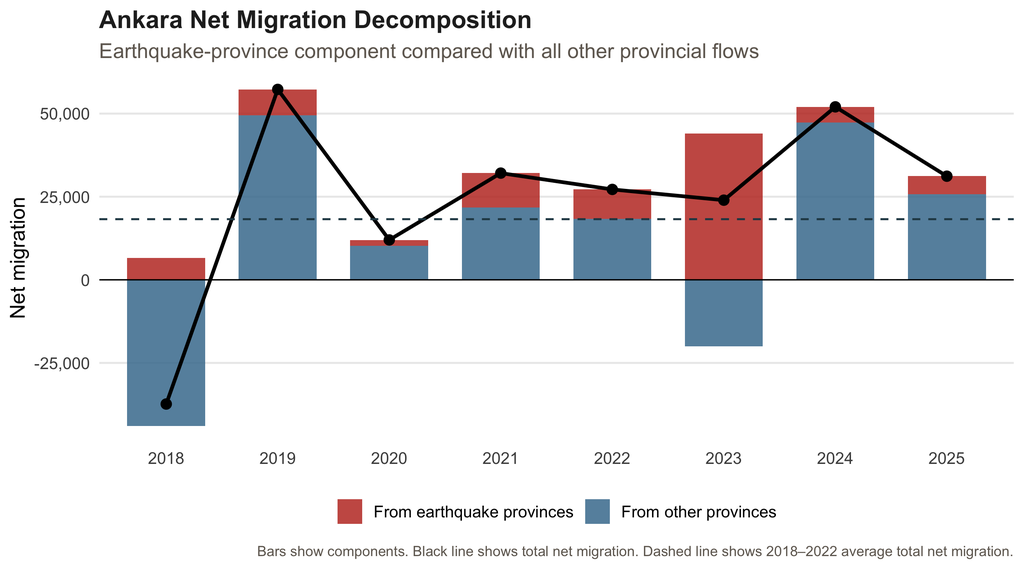

Ankara’s net migration from earthquake provinces and other provinces, 2018–2025.

```r
ankara |>
  select(year, `From earthquake provinces` = net_eq, `From other provinces` = net_non_eq) |>
  pivot_longer(-year, names_to = "component", values_to = "value") |>
  ggplot(aes(factor(year), value, fill = component)) +
  geom_col(width = 0.7, alpha = 0.85) +
  geom_line(
    data = ankara,
    aes(x = factor(year), y = net_total, group = 1),
    inherit.aes = FALSE,
    color = "black",
    linewidth = 1.1
  ) +
  geom_point(
    data = ankara,
    aes(x = factor(year), y = net_total),
    inherit.aes = FALSE,
    color = "black",
    size = 2.6
  ) +
  geom_hline(yintercept = baseline_total, linetype = "dashed", color = "#264653") +
  geom_hline(yintercept = 0, linewidth = 0.4) +
  scale_fill_manual(values = c(
    "From earthquake provinces" = "#c0392b",
    "From other provinces" = "#457b9d"
  )) +
  scale_y_continuous(labels = label_comma()) +
  labs(
    title = "Ankara Net Migration Decomposition",
    subtitle = "Earthquake-province component compared with all other provincial flows",
    x = NULL,
    y = "Net migration",
    fill = NULL,
    caption = "Bars show components. Black line shows total net migration. Dashed line shows 2018–2022 average total net migration."
  ) +
  theme(
    panel.grid.major.x = element_blank(),
    legend.position = "bottom",
    plot.title = element_text(face = "bold")
  )
```

The chart below shows gross in- and out-migration separately, as net figures alone do not distinguish between more arrivals and fewer departures.

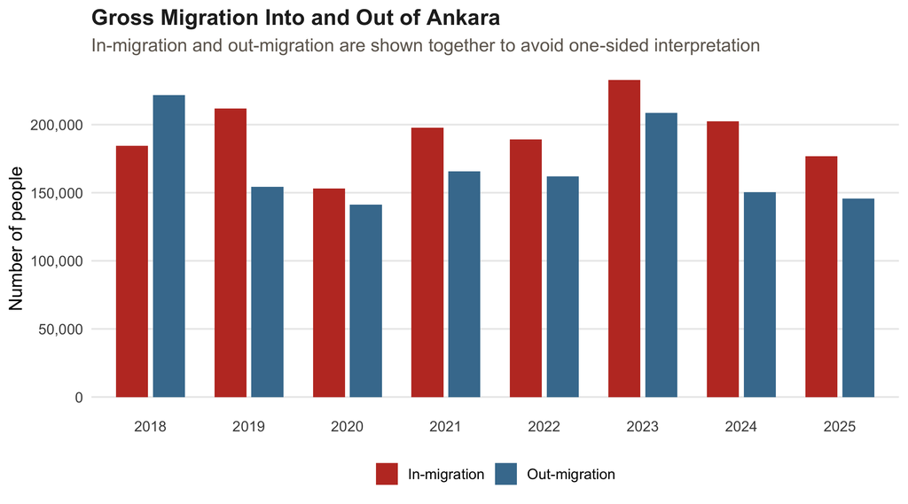

Gross in-migration and out-migration into/from Ankara, 2018–2025.

```r
ankara |>
  select(year, `In-migration` = total_in, `Out-migration` = total_out) |>
  pivot_longer(-year, names_to = "flow_type", values_to = "people") |>
  ggplot(aes(factor(year), people, fill = flow_type)) +
  geom_col(position = position_dodge(0.75), width = 0.65) +
  scale_fill_manual(values = c("In-migration" = "#c0392b", "Out-migration" = "#457b9d")) +
  scale_y_continuous(labels = label_comma()) +
  labs(
    title = "Gross Migration Into and Out of Ankara",
    subtitle = "In-migration and out-migration are shown together to avoid one-sided interpretation",
    x = NULL,
    y = "Number of people",
    fill = NULL
  ) +
  theme(
    panel.grid.major.x = element_blank(),
    legend.position = "bottom",
    plot.title = element_text(face = "bold")
  )
```

The table below shows how in-migration to Ankara in 2023 was distributed across the eleven earthquake-affected provinces.

```r
full_mig |>
  filter(year == 2023, dest == "ANKARA", origin %in% EQ_KEYS) |>
  mutate(
    province_label = PROVINCE_LABELS[origin],
    share = in_f / sum(in_f, na.rm = TRUE) * 100
  ) |>
  arrange(desc(net_f)) |>
  transmute(
    Province = province_label,
    `In-Migration` = round(in_f, 0),
    `Out-Migration` = round(out_f, 0),
    `Net Migration` = round(net_f, 0),
    `Share of EQ inflow (%)` = round(share, 1)
  ) |>
  knitr::kable()
```

Migration from each earthquake province into Ankara in 2023.

| Province | In-Migration | Out-Migration | Net Migration | Share of EQ inflow (%) |
| --- | --- | --- | --- | --- |
| Hatay | 18356 | 2153 | 16203 | 29.0 |
| Malatya | 11470 | 1649 | 9821 | 18.2 |
| K.Maraş | 8564 | 1519 | 7045 | 13.6 |
| Adıyaman | 4136 | 974 | 3162 | 6.5 |
| Adana | 5508 | 2763 | 2745 | 8.7 |
| Gaziantep | 4197 | 2536 | 1661 | 6.6 |
| Diyarbakır | 3588 | 2476 | 1112 | 5.7 |
| Osmaniye | 2026 | 982 | 1044 | 3.2 |
| Ş.Urfa | 3299 | 2604 | 695 | 5.2 |
| Elazığ | 1764 | 1235 | 529 | 2.8 |
| Kilis | 284 | 339 | -55 | 0.4 |

# 7 Key Takeaways

1. Damage intensity was not evenly distributed across the earthquake region; Hatay, Malatya, Adıyaman, and Kahramanmaraş stood out with the highest heavy-damage burden per 1,000 residents.
2. The strongest population losses in 2023 were observed in provinces with higher heavy-damage intensity, suggesting a visible relationship between physical destruction and demographic decline.
3. Migration flows from earthquake-affected provinces were directed not only toward major metropolitan areas such as Istanbul, Ankara, and Antalya, but also toward nearby regional destinations.
4. Recovery by 2025 remained uneven; some provinces approached or exceeded their expected population trend, while the hardest-hit provinces still showed a demographic gap.
5. The Ankara-specific analysis shows that earthquake-origin inflows increased in 2023, but total net migration should be interpreted together with outflows and other provincial movements.

# 8 Conclusion

As of 2025, the recovery process is not yet complete, and significant differences are observed between provinces. While some provinces have approached or exceeded their pre-earthquake demographic trends, the provinces that suffered the heaviest destruction continue to lag behind expected population levels. When migration flows to Ankara are examined, it is seen that inflows from earthquake zones increased significantly in 2023, but the total net migration continues to be shaped by movements from other provinces.

# References

Turkish Statistical Institute (TÜİK). (2026). *Address Based Population Registration System Results, 2025*. TÜİK Data Portal. Retrieved from the TÜİK official data portal.

Turkish Statistical Institute (TÜİK). (2026). *Internal Migration Statistics*. TÜİK Data Portal. Retrieved from the TÜİK official data portal.

Disaster and Emergency Management Presidency (AFAD). (2023). *February 6, 2023 Kahramanmaraş Earthquakes and Damage Assessment Data*. Republic of Türkiye Ministry of Interior, AFAD.

Presidency of Strategy and Budget. (2023). *2023 Kahramanmaraş and Hatay Earthquakes Report*. Republic of Türkiye Presidency of Strategy and Budget.

Alpers, K. (n.d.). *Turkey Maps GeoJSON: tr-cities.json*. GitHub repository.

Back to top